# Rmarkdown

Sophie C. Schmidt

```r
knitr::opts_chunk$set(echo = TRUE)

library(ggplot2)
library("palmerpenguins")
data("penguins")
```

## Style guide

Damit man seinen eigenen Code später auch noch gut lesen kann und auch andere Leute ihn gut lesen können, gibt es ein paar Hinweise, wie er geschrieben wird, sogenannte "style guides". Ich orientiere mich an dem Style Guide der "Initiative für Statistische Analysen in Archäologie Kiel" (https://github.com/ISAAKiel/StyleGuide) und gebe euch hier ein paar Hinweise:

1. Leerzeichen um jeden Operator (`=, +, -, <-`, etc.)) herum, kein Leerzeichen vor einem Komma, aber eins dahinter.
2. Namen von Datensätzen und Variablen sollten keine Sonderzeichen enthalten. Leerzeichen sollten mit einem Unterstrich _ ersetzt werden. "Sprechende" Namen, die einen Sinn ergeben, sind nützlich (zB `mean_body_mass_g` und nicht einfach nur `m`).
3. Eine Zeile Code sollte nicht länger als 80 Zeichen sein. Stattdessen ist es sinnvoll, den Code hinter jedem Komma "umzubrechen", denn dann hat an einen besseren Überblick und kann ihn viel besser kommentieren (siehe 4.). Rstudio "setzt" das auch von alleine sinnvoll, in dem die neue Zeile innerhalb einer Klammer dann auf der gleichen "Höhe" beginnt, wie der vorhergehende Eintrag.
4. Kommentiert den Code mit einem Hashtag (#)-Symbol.
- VOR dem Code und in eine eigene Zeile kommen längere Hinweise, was der folgende Code machen soll: zB "# Histogramm erstellen, um Verteilung der Größe der Pinguine einzuschätzen"
- IN DIE GLEICHE ZEILE wie Code kommen kurze Hinweise auf die genutzte Funktionen und Argumente, zB:

```r
library(ggplot2)
library("palmerpenguins")
data("penguins")

# Histogramm erstellen, um Verteilung der Größe der Pinguine einzuschätzen
ggplot()+
  geom_histogram(data = penguins, aes(x = body_mass_g),
                 binwidth = 100, # Klassengröße 100g zeigt klare Verteilungsstrukturen
                 na.rm = TRUE) # zwei NA-Sätze müssen entfernt werden
```

- lieber zu viel als zu wenig kommentieren.
5. Lasst ein bisschen Platz zwischen verschiedenen Sinneinheiten im Code. Eine Leerzeile zwischen `data("penguins")` und dem Kommentar im Bsp erleichtert das Lesen ungemein.

## R Markdown

Als erstes: bitte Rmarkdown installiern>

```r
install.packages("rmarkdown")
```

Ein *Rmarkdown*-Dokument (Rmd) ist eigentlich nur ein txt-Dokument, also das simpelste an Textdatei was man sich vorstellen kann. In dem ich in dieser Textdatei einer bestimmten Syntax folge, kann ich die Datei von einem Programm im Hintergrund (namens pandoc) in hübsch formatierte Word-, html- oder PDF-Dateien umwandeln. Zum Bsp lassen sich Überschriften mit dem Rautensymbol markieren, Listen mit einem einfach Minus-Symbol und Text durch Unterstriche *kursiv* und durch zwei Sternchensymbole **fett** drucken.

[figure not shown]

(Beispiel von der offiziellen homepage)

### Dokument-Struktur

Fangen wir in einem Dokument von oben an. Ganz oben steht ein sogenannter "YAML-Header". Er beginnt mit drei Minus-Zeichen und endet mit 2 Minuszeichen in einer eigenen Zeile. In ihm werden einige Meta-Daten zu dem Dokument abgelegt:

- Der Titel wird hinter `title:` in Hochkommas geschrieben
- Hinter `author:` schreibt man seinen eigenen Namen in Hochkommas
- `date:` ist nichr verpflichtend, aber das kann hilfreich sein
- und mit `output:` wird spezifiziert, in was für eine Art Dokument das Rmarkdown-Dokument verwandelt werden soll. "html_document" wurde hier gewählt, es geht aber auch "word_document" oder "pdf_document" und tatsächlich noch eine R-Markdown spezifische Versionen, die hier nicht so wichtig sind.

Wenn das Paket `knitr` installiert ist (bitte installiert es), gibt es oben den **Knit**-Knopf (englisch für stricken und das Symbol ist ein Wollknäul mit Stricknadeln), der das Dokument umwandelt. Wer faul ist wie ich, benutzt den Shortcut Strg+Umschalt+k.

Überschriften werden in einer einfachen Syntax gegliedert. Ein Hashtag (#) markiert die oberste Überschrift, zwei Hashtags (##) die zweite Rangordnung, drei Hashtags (###) die nächste. "Dokument-Struktur" ist eine Überschrift dritten Grades: `### Dokument-Struktur{#dokument-struktur}`.

Ach, was soll denn dieses `{#dokument-struktur}`? Das setzt einen Anker. Mit einem Anker kann ich links innerhalb des Dokuments setzen. Also, auf andere Überschriften verweisen. Wer html kennt, dem ist das Prinzip bekannt. Wenn ihr hierauf klickt, dann springt ihr wieder zu der Überschrift Dokument-Struktur. Markiert wurde das folgendermaßen: `[hierauf](#dokument-struktur)`.

Praktisch, nicht wahr? Ein Anker steht in geschweiften Klammern ({}) und beginnt mit einer Rautensymbol (#). Er darf keine Leerzeichen enthalten! Wenn auf den Anker verwiesen werden soll, wird er in runde Klammern () hinter das Wort in eckigen Klammern [], das als Link formatiert wird, geschrieben.

So viele Rauten... Hashtags... ### ... Hilfe!

Nicht verwirren lassen! Innerhalb eines Code-Chunks und innerhalb eines "normalen R-Skripts" gilt die Raute als Symbol zum Markieren von Kommentaren. Im Text-Teil eines Markdown-Dokuments zeichnet es eine Überschrift aus, wenn davor und danach eine Leerzeile steht. In geschweiften Klammern ({}) beginnt ein Hasthag einen Anker, in runden Klammern () wird daraus ein Link, der auf den Anker verweist.

### Text und Code (das R in RMarkdown)

In einem Rmd gibt es "normale" Textbereiche, wie diesen hier und Code Chunks: Code chunks sind die Bereiche, in denen ich Code unterbringen kann. Man erstellt am einfachsten einen mit dem Shortcut Strg+Alt+i.

Sie folgen einer bestimmten Logik und werden durch drei Hochkommas (``` = die Art, die man auf der deutschen Tastatur neben dem Back-Pfeil findet) und einer öffnenden geschweiften Klammer mit einem r darin geöffnet. Daneben kann ich den Code Chunk benennen. Kann voll praktisch sein, wenn ich später mal darauf referenzieren möchte. Dahinter kann man noch Parameter für den Code Chunk setzen, dazu gleich mehr. Nach diesen Parametern folgt jedoch eine schließende geschweifte Klammer und der Bereich für Code beginnt. Er ist immer etwas dunkler hinterlegt. In diese erste Zeile sollte nichts weiter hinter die geschweifte Klammer kommen.

Der Code Chunk muss aber auch beendet werden. Dafür braucht man wieder die drei Hochkommas alleine (```) in einer Zeile.

```r
# das hier ist ein Code Chunk. Ich sollte also nur Code hinein schreiben
# alles was nicht Code ist, muss auskommentiert werden, sonst will pandoc es gerne als Code behandeln und fängt an zu weinen, weil es sehr fehlerhafter Code wäre
```

Dieser Code wird in der Regel gleich ausgeführt und, wenn er zu einer Grafik führen soll, wird die Grafik angezeigt:

[figure not shown]

(Mehr zum Bilder einfügen hier)

Die Parameter des Code Chunks können bestimmen, ob der Code mit als Code in das html-Dokument übertragen werden werden soll (echo = TRUE) oder nicht (echo = FALSE) oder falls ein Diagramm erstellt wird, wie groß es sein soll (fig.height und fig.width). Einen Parameter, den ich immer benutze, um die Skripte zu erstellen, ist zB "eval = FALSE", was besagt, dass der Code in diesem Chunk nicht ausgeführt werden soll. Ansonsten würde ich bei jedem Umwandeln des RMarkdown-Dokuments in die html alle Pakete neu installieren, deren Installationscode ich hinschreibe, das wäre Quatsch. Diese Parameter werden mit Komma voneinander getrennt, weitere findet ihr unter: https://rmarkdown.rstudio.com/lesson-3.html und eine super Zusammenstellung hier: https://yihui.org/knitr/options/. Man kann sie aber auch händisch einstellen, wenn man auf das kleine Zahnradsymbol klickt.

Noch ein Beispiel für einen Code Chunk. Ich möchte das Histogramm aus dem Beispiel oben in dieses Dokument einfügen. Diesmal gebe ich nicht den Parameter `eval = FALSE` sondern `eval = TRUE` und spezifiziere, dass die Grafik 5cm groß sein soll. Dadurch dass in meinem obersten Code Chunk in diesem Dokument im setup `knitr::opts_chunk$set(echo = TRUE)` gesetzt habe, gilt `echo = TRUE` als default für alle Code Chunks. Damit wird der Code immer mit ausgeschrieben.

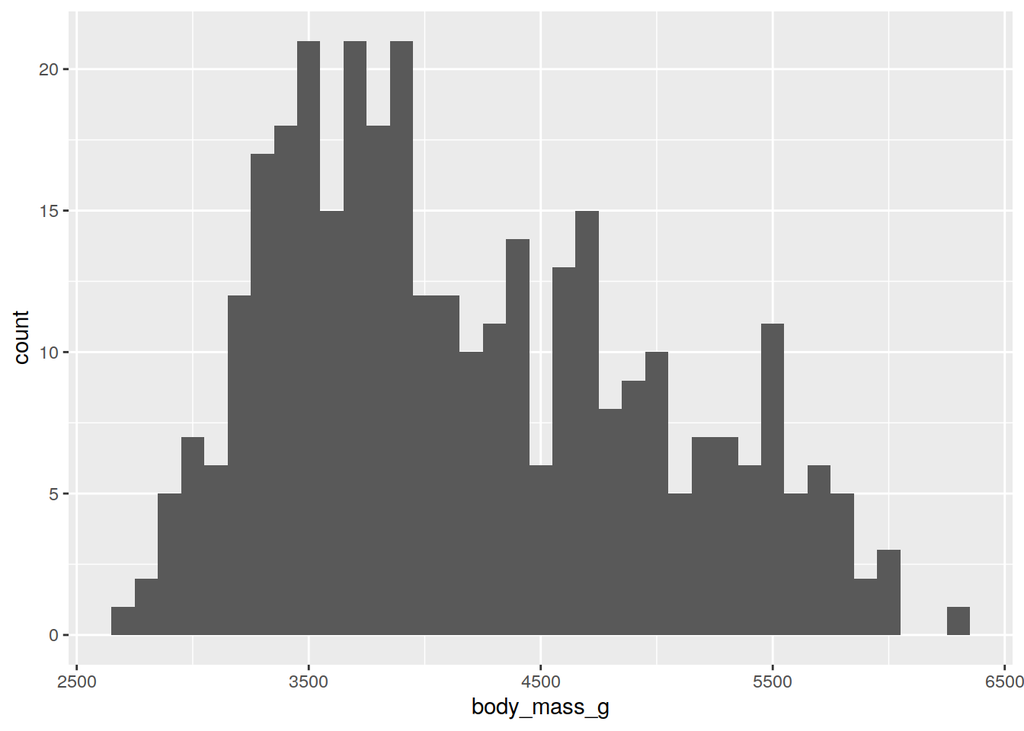

```r
library(ggplot2)
library("palmerpenguins")
data("penguins")

# Histogramm erstellen, um Verteilung der Größe der Pinguine einzuschätzen
ggplot()+
  geom_histogram(data = penguins, aes(x = body_mass_g),
                 binwidth = 100, # Klassengröße 100g zeigt klare Verteilungsstrukturen
                 na.rm = TRUE) # zwei NA-Sätze müssen entfernt werden
```

Wenn ich das nicht möchte, muss ich noch einmal in meinen Code Chunk Options spezifizieren, dass `echo = FALSE` sein soll. Bsp:

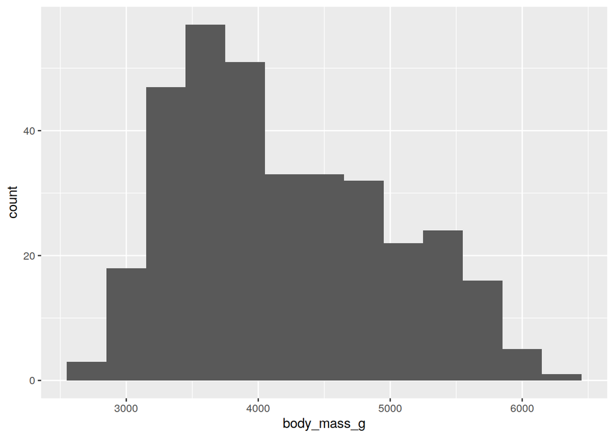

Außerhalb eines Code Chunks weiß pandoc jedoch nicht, dass was ich schreibe, Code sein soll, es geht davon aus, dass das alles Text ist.

install.packages("knitr") tut also genau gar nichts.

Was man aber machen kann, ist Variablen, die man erstellt hat, und kleine Berechnungen im Text einbetten. Man brauch ein Hochkomma ` r "Variablenname / Befehl" und wieder ein Hochkomma ´ einfach mitten im Fließtext. Der Median von der Spalte body_mass_g ist 4050g. Geschrieben habe ich nicht die Zahl sondern: ` r median(penguins$body_mass_g, na.rm = TRUE)` und das Programm hat es sozusagen "on the fly" im Text für mich ausgerechnet.

Das ist suuuuper praktisch, weil ich mir so keine Zahlen merken muss und so eine Fehlerquelle reduziere.

### Bilder einfügen

Die Bilder im Text habe ich per Markdown eingefügt. Sie sind online verfügbar, deshalb war der Code für das erste der folgende: `![](https://d33wubrfki0l68.cloudfront.net/44f781299f23419d5314e5322e7c44393f7190d3/c5915/images/markdownchunk.png)`. Um Bilder einzufügen, die irgendwoe auf meinem PC liegen, gilt: `![](Pfad/zum/Bild/bild.jpg`)

Links lassen sich auch einfügen, und zwar als [Hyperlink im Text](https://rmarkdown.rstudio.com/authoring_quick_tour.html) (Code: `[Hyperlink im Text](https://rmarkdown.rstudio.com/authoring_quick_tour.html`)

oder einfach so: https://rmarkdown.rstudio.com/authoring_quick_tour.html.

### Zusammenfassung

RMarkdown verknüpft Markdown, eine Auszeichnungssprache mit Möglichkeiten R-Code auszuführen. Der große Vorteil eines RMarkdown-Dokumentes ist es, dass man seinen Code und den Text zur Interpretation beisammen hat. So lassen sich direkt Zeitschriftenartikel mit Berechnungen, Analysen, Grafiken etc in einem Dokument ablegen. Man kann in Markdown mit einem Literaturverwaltungsprogramm zusammenarbeiten und sich automatisch Literaturverzeichnisse generieren lassen, mehr dazu später.

### Links

Wer mehr zu Markdown allgemein lesen will, sei hierauf verwiesen: https://vijual.de/2019/03/11/artikel-mit-markdown-und-pandoc-schreiben/ (insb. Kap 1). Details zu RMarkdown findet ihr hier: http://rmarkdown.rstudio.com und einen sehr praktischen Schummelzettel hier: https://rstudio.com/wp-content/uploads/2015/06/rmarkdown-german.pdf . Hilfreich ist auch dieses Buch: https://bookdown.org/yihui/rmarkdown.